# Iteration and Looping

## Conditionals in R

Conditionals are statements that evaluate a logical statement and then make a choice. They are a simple programming concept that can build in a lot of power and flexibility to your R scripting. The most straight-forward of the conditional statements are the simple **if** and **if/else**.

Remember that the symbol for logical equivalence is the double equal sign **==**.

```r
if (day=="Monday") {
  print("yesterday")
} else {
  print("not yesterday")
}
```

```
[1] "not yesterday"
```

Anything that evaluates to **TRUE** or **FALSE** can be put into a conditional statement. You can also use the logical operators **&**(and), **|**(or), or **!**(not) in your conditional statements.

```r
if (julian.date >= 65) {
  print("It's after March 6th")
}
```

```
[1] "It's after March 6th"
```

## Iteration and looping

Iteration and looping in R is useful for when you need to do the same operation over a set of objects, datasets, or observations, or when you want to run some simulations. You can easily set up iteration in R over multiple variables (as long as you can keep your head around that they’re doing!). The basic iterator in R is the **for()** function.

Check out this example of the basic for loop syntax.

```r
for (i in 1:10) {  # Basic structure
  print(i)        # i is the "iterator". It's a counter in this case.
}
```

```
[1] 1
[1] 2
[1] 3
[1] 4
[1] 5
[1] 6
[1] 7
[1] 8
[1] 9
[1] 10
```

One important thing to note about iterating using **for** in R is that R takes care of moving through all of the iterations on it’s own. In the example above, you don’t need to tick **i** up by one each time. (This is not always the case with other programming languages!).

Another iterator in R is **while**. While is useful for when you need to repeat something until you meet some sort of condition - i.e., you don’t know how many times you want to repeat ahead of time. Examples of this would be running a simulation until it stabilizes or reaches some threshold, or recursive parsing of a document for text patterns. *Be careful with while(), though, because it’s easy to get into never-ending (infinite) loops.*

```r
# simple while example to replicate a for loop
i <- 0
while (i < 10) {
  print(i)
  i<-i+1  # Need to count up i by one each time in this case.
}

now <- Sys.time()
while (Sys.time() < now+10) {
  print("waiting...")
}
print("It's now 10 seconds later!")
```

You can also iterate over lists of objects. This becomes really powerful if you need to do the same thing over a bunch of datasets.

```r
for (month in c("Jan","Feb","Mar","Apr","May")) {
  print(month)
}
```

```
[1] "Jan"
[1] "Feb"
[1] "Mar"
[1] "Apr"
[1] "May"
```

Use different R functions to create sets of objects to iterate over

```r
for (rand.num in rnorm(12)) { # Iterate over a set of 12 random numbers
  print(paste("The Random number is: ",rand.num))
}
```

```
[1] "The Random number is:  1.03523799792207"
[1] "The Random number is:  0.512548489970157"
[1] "The Random number is:  -0.89728721072203"
[1] "The Random number is:  0.989035076830111"
[1] "The Random number is:  -0.163487696487919"
[1] "The Random number is:  -0.892326126460966"
[1] "The Random number is:  0.587502130027825"
[1] "The Random number is:  -0.690580674440785"
[1] "The Random number is:  -1.18097769769985"
[1] "The Random number is:  -0.744715515964738"
[1] "The Random number is:  -0.317489085273704"
[1] "The Random number is:  -0.188690771538169"
```

Grab a list of files from a directory and iterate over those

```r
for (file in files) {
  print(file)
  out.data[[file]]<-read.csv(paste(data.path,file,sep="\\"))
}
```

```
[1] "Cow_14_GPS_July_2017.csv"
[1] "GPSLOG_5min_Indoor.20180314.csv"
[1] "GPSLOG_5min_Outdoor.20180313.csv"
[1] "height_compare_sims.csv"
[1] "IBP_RapidEyeOrtho_Availability.csv"
[1] "PRISM_ppt_CraigMountain_1900-2018.csv"
[1] "some_data_to_save.csv"
[1] "tidy_YST_data.csv"
```

For simulations, you can use loops to build your results

```r
out.data <- data.frame() # set up an empty data frame
for (i in 1:10) {
  var.rand <- rnorm(1)
  var.now <- date()
  var.other <- "Jason"
  out.row <- data.frame(i=i, rand=var.rand, now=var.now, me=var.other) # Assemble your new data
  out.data <- rbind(out.data,out.row) # Append it to your out dataframe
}
glimpse(out.data)
```

```
Observations: 10
Variables: 4
$ i    <int> 1, 2, 3, 4, 5, 6, 7, 8, 9, 10
$ rand <dbl> 0.3839, 1.2397, 0.5142, -1.8824, -0.6935, 0.6719, 1.3750, 0.5252, 0.0672, -2.4599
$ now  <fct> Wed Mar 06 16:43:54 2019, Wed Mar 06 16:43:54 2019, Wed Mar 06 16:43:54 2019, ...
$ me   <fct> Jason, Jason, Jason, Jason, Jason, Jason, Jason, Jason, Jason, Jason
```

You can also nest for loops

```r
out.data <- data.frame() # set up an empty data frame
for (x in seq(-3,3,by=0.1)) {  # Note use of seq() here.
  for (y in seq(-3,3,by=0.1)) {
    z <- exp(-((x-0)^2/2+(y-0)^2/2)) ## 2D gaussian formula with mean zero and variance of 1
    out.row <- data.frame(x=x, y=y, z=z)
    out.data <- rbind(out.data,out.row)
  }
}
glimpse(out.data)
```

```
Observations: 3,721
Variables: 3
$ x <dbl> -3, -3, -3, -3, -3, -3, -3, -3, -3, -3, -3, -3, -3, -3, -3, -3, -3, -3, -3, -3, -...
$ y <dbl> -3.0, -2.9, -2.8, -2.7, -2.6, -2.5, -2.4, -2.3, -2.2, -2.1, -2.0, -1.9, -1.8, -1....
$ z <dbl> 0.000123, 0.000166, 0.000220, 0.000290, 0.000378, 0.000488, 0.000624, 0.000789, 0...
```

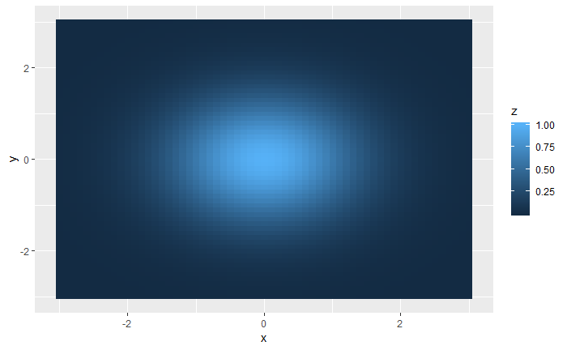

```r
ggplot(data=out.data,aes(x=x,y=y,fill=z))+geom_raster()
```